# Data Science 1 - Assignment 1

Attila Serfozo

2021.03.18

# 1. Tree ensemble models

In the first exercise we are going to work with the OJ dataset, which records purchases of two types of orange juices (Citrus Hill and Minute Mad) and presents customer and product characteristics as features. The goal is to predict which of the juices is chosen in a given purchase situation.

### a. Create a training data of 75% and keep 25% of the data as a test set. Train a decision tree as a benchmark model. Plot the final model and interpret the result (using rpart and rpart.plot is an easier option).

The plot of a basic decision tree can be seen below. Based on the tree the most important predictor is customer loyalty towards Citrus Hill which appears at many cuts of the decision tree.

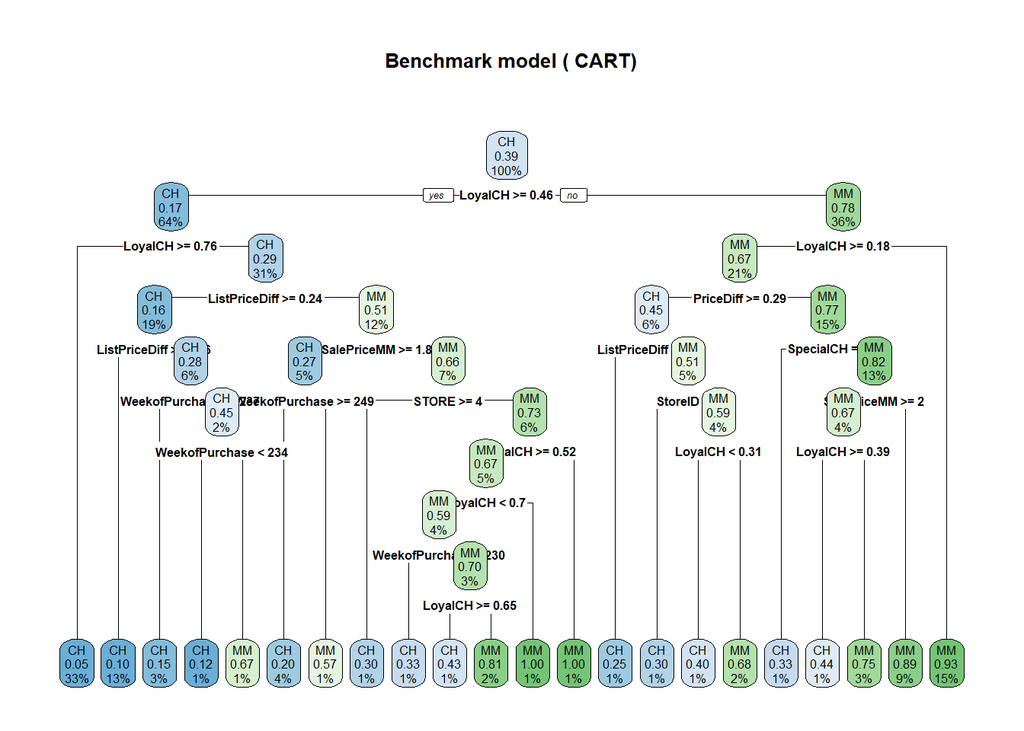

### b. Investigate tree ensemble models: random forest, gradient boosting machine, XGBoost. Try various tuning parameter combinations and select the best model using cross-validation.

After running a cart model as benchmark, I had a look at random forest, gradient boosting machine and xgboost models. For random forest I tried different number of mtry parameters and node size, in the end the mtry of 8 and node size of 40 were the best tune parameters.

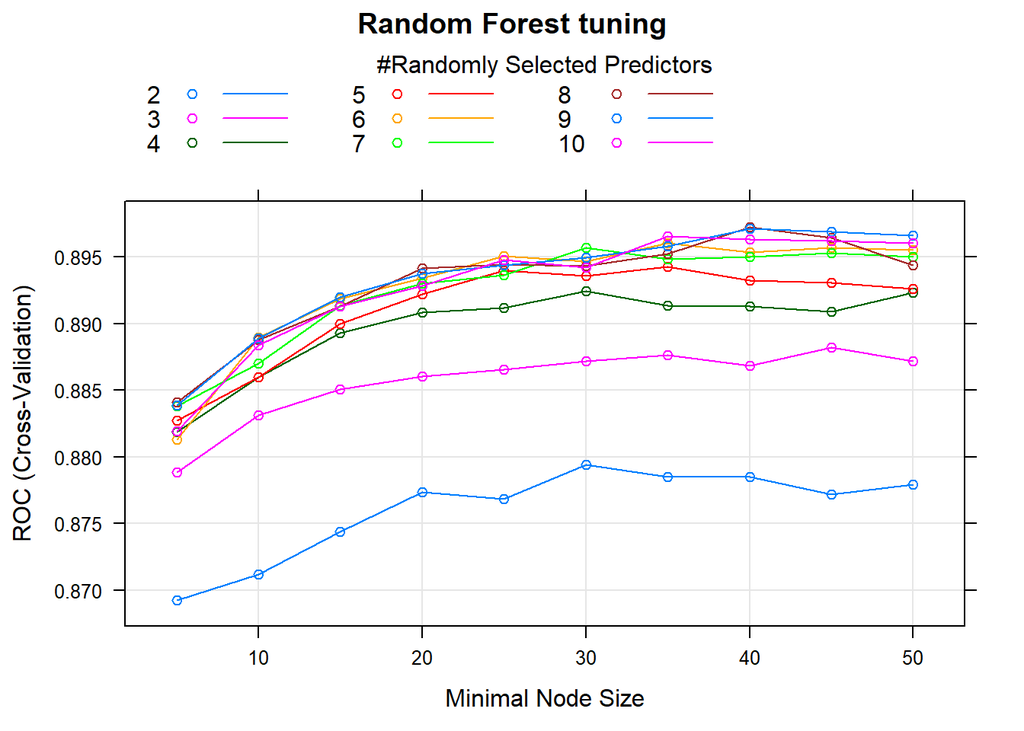

For GBM I tried different number of trees, level of depth, node size and shrinkage parameters. In the end the best ROC was with 100 trees, 5 interaction depth, 0.05 shrinkage and 10 min node size.

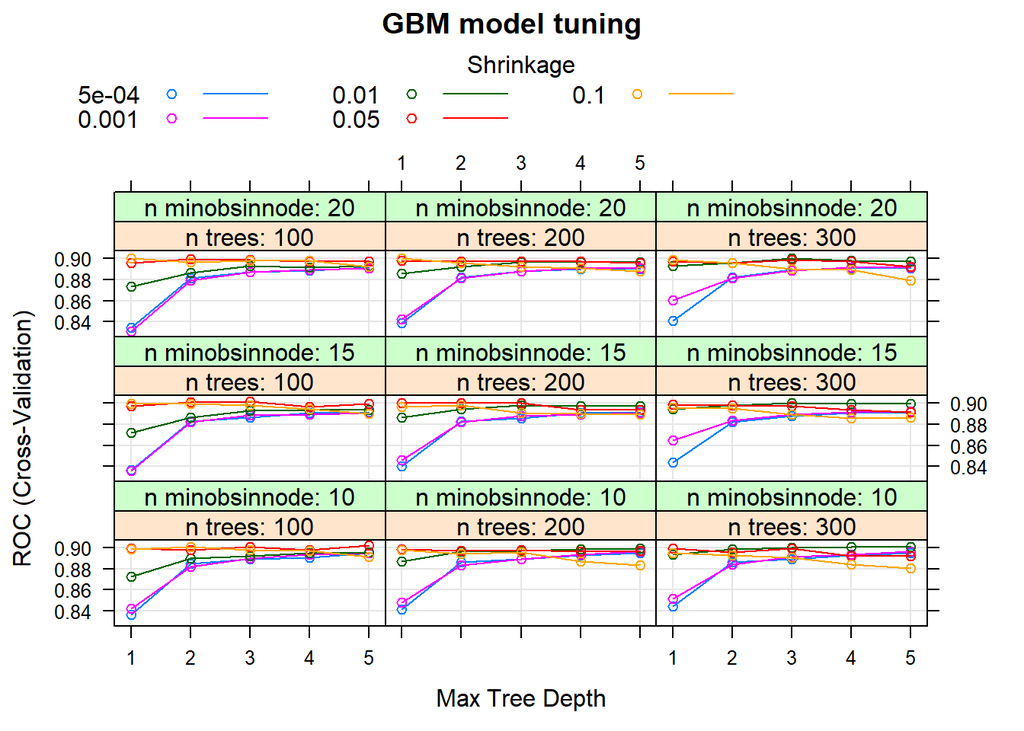

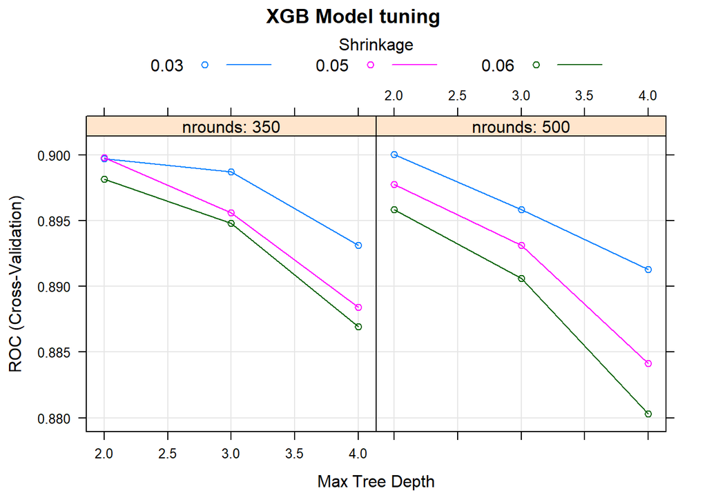

### c. Compare the performance of the different models (if you use caret you should consider using the resamples function). Make sure to set the same seed before model training for all 3 models so that your cross validation samples are the same. Is any of these giving significantly different predictive power than the others?

As it can be seen below the Random Forest, GBM and XGBoost were both close regarding the ROC, but the GBM and XGBoost achieved to get above 90%, the GBM had the best results a slightly in front of the XGBoost. The benchmark (cart) model has a less significant prediction power compared to the others.

Models ROC

|  | CART | Random_Forest | GBM | XGBoost |
| --- | --- | --- | --- | --- |
| . | 0.86896 | 0.8972 | 0.90212 | 0.90006 |

### d. Choose the best model and plot ROC curve for the best model on the test set. Calculate and interpret AUC.

Models AUC

|  | CART | Random_Forest | GBM | XGBoost |
| --- | --- | --- | --- | --- |
| . | 0.86896 | 0.8889 | 0.85432 | 0.8926 |

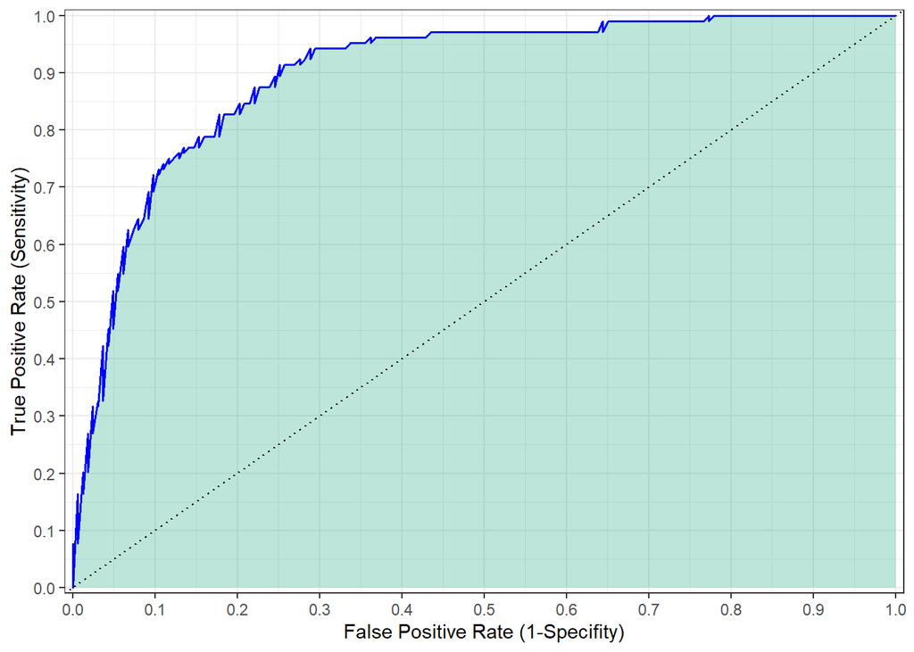

### e. Inspect variable importance plots for the 3 models. Are similar variables found to be the most important for the 3 models?

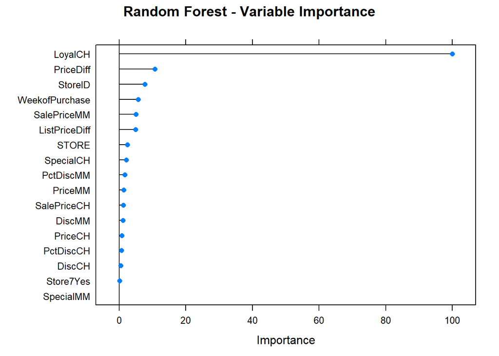

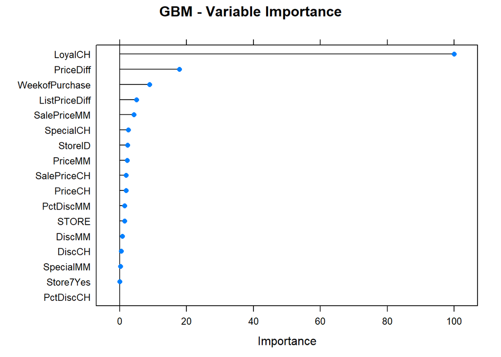

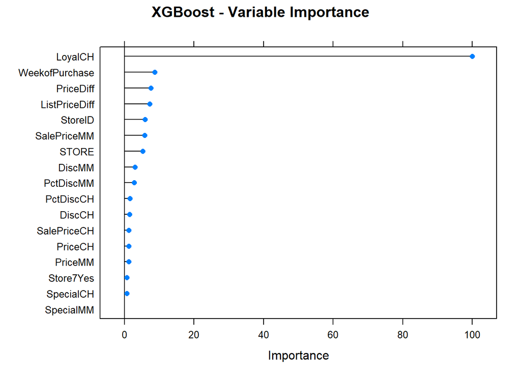

# 2. Variable importance profiles ——————————————–

In the second exercise we are going to work with the Hitters dataset, which records baseball players and their salaries. The goal is to check variable importance plots for interesting facts.

### a. Train two random forest models: one with sampling 2 variables randomly for each split and one with 10 (use the whole dataset and don’t do cross-validation). Inspect variable importance profiles. What do you see in terms of how important the first few variables are relative to each other?

The variable plots of the two models can be found below. We can see that in case of the tree sampling 2 variables randomly the variable importance is well balanced. In contrary, in the tree sampling 10 variables 3 variables are over represented in the trees with high variable importance, while others are penalized with low importance.

```
## Random Forest
##
## 263 samples
##  19 predictor
##
## No pre-processing
## Resampling: Bootstrapped (25 reps)
## Summary of sample sizes: 263, 263, 263, 263, 263, 263, ...
## Resampling results across tuning parameters:
##
##   min.node.size  RMSE    Rsquared  MAE
##    5             0.4308  0.7715    0.3017
##   10             0.4315  0.7713    0.3021
##
## Tuning parameter 'mtry' was held constant at a value of 2
## Tuning
##  parameter 'splitrule' was held constant at a value of variance
## RMSE was used to select the optimal model using the smallest value.
## The final values used for the model were mtry = 2, splitrule = variance
##  and min.node.size = 5.
```

```
## Random Forest
##
## 263 samples
##  19 predictor
##
## No pre-processing
## Resampling: Bootstrapped (25 reps)
## Summary of sample sizes: 263, 263, 263, 263, 263, 263, ...
## Resampling results across tuning parameters:
##
##   min.node.size  RMSE    Rsquared  MAE
##    5             0.4397  0.7587    0.3076
##   10             0.4400  0.7585    0.3078
##
## Tuning parameter 'mtry' was held constant at a value of 10
## Tuning
##  parameter 'splitrule' was held constant at a value of variance
## RMSE was used to select the optimal model using the smallest value.
## The final values used for the model were mtry = 10, splitrule = variance
##  and min.node.size = 5.
```

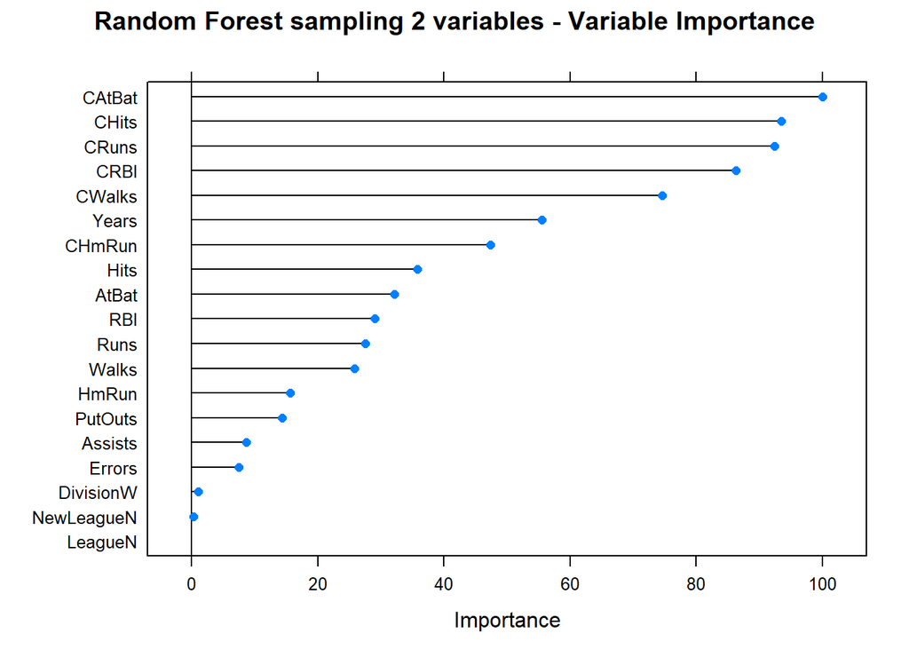

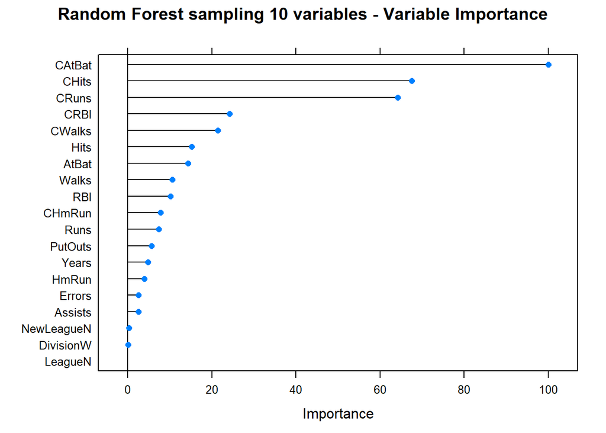

### b. One of them is more extreme in terms of how the most important and the next ones relate to each other. Give an intuitive explanation how mtry/mtries relates to relative importance of variables in random forest models.

The model with less - 2 - mtry chooses from fewer number of variables, as a result the variable importance is more distributed. The model with 10 mtry value includes more variables at the cuts selection which means it more often chooses the CatBar variable.

### c. In the same vein, estimate two gbm models with varying rate of sampling for each tree (use 0.1 and 1 for the parameter bag.fraction/sample_rate). Hold all the other parameters fixed: grow 500 trees with maximum depths of 5, applying a learning rate of 0.1. Compare variable importance plots for the two models. Could you explain why is one variable importance profile more extreme than the other?

In case of GBM the different sampling rates means different number of rows included for modelling (lower subsample rate means fewer rows for tree growing), which results more distributed variable importance.

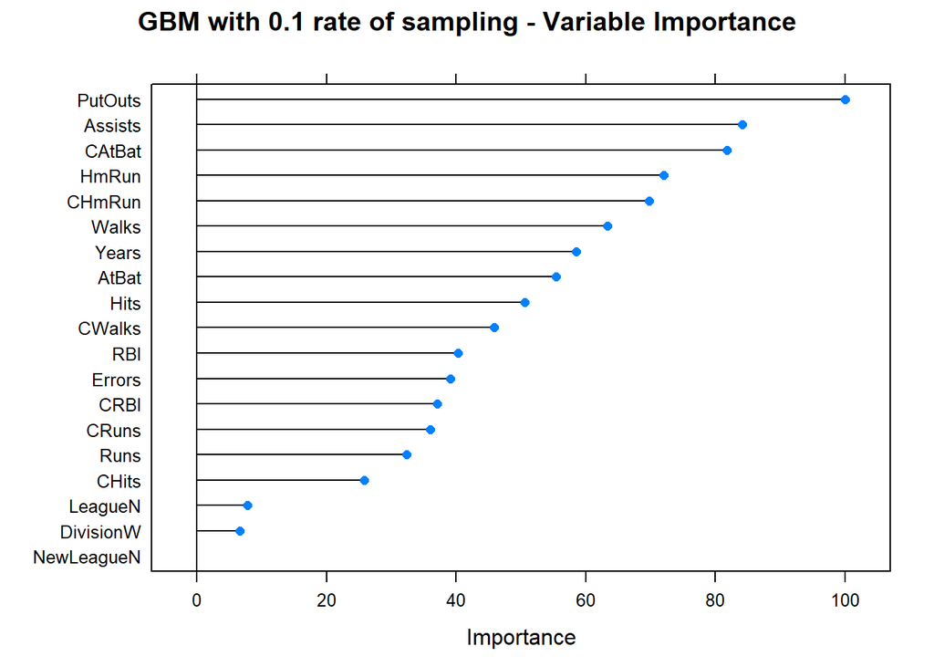

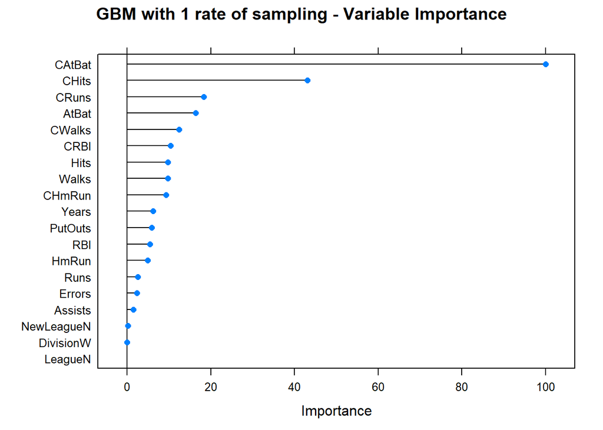

# 3. Stacking —————————————————————-

Our goal on the third dataset is to predict whether a patient will actually show up for their medical appointments. For this exercise I will use h2o to do the predictions.

### a. Create train / validation / test sets, cutting the data into 5% - 45% - 50% parts.

First I separated the dataset into a training (5%), validation (45%) and test set (50%).

### b. Train a benchmark model of your choice (such as random forest, gbm or glm) and evaluate it on the validation set.

I first trained a linear model as a benchmark model, which performed relatively good results with an AUC of 0.5648 on the training set and a similar AUC of 0.5729 on the validation set.

### c. Build at least 3 models of different families using cross validation, keeping cross validated predictions. You might also try deeplearning.

In the following I train a random forest another linear model and a gradient boosting machine to try to overperform the results of the benchmark model. To achieve a better performance I also tried different tuning parameters, the results (AUCs) on the training dataset ca be found below. As we can see the random forest and glm could not overperform significantly the benchmark model, meanwhile the GBM achived a 0.6 AUC which is well above the benchmark models 0.5729 AUC.

Models AUC on training set

|  | CV AUC |
| --- | --- |
| Random_Forest | 0.5740 |
| GLM | 0.5713 |
| GBM | 0.6008 |

### d. Evaluate validation set performance of each model.

Finally I ran every model on the validation set as well, all of them performed well, but the random forest performed better on the validation set compared to its performance on the training set.

Models AUC on validation set

|  | CV AUC |
| --- | --- |
| Random_Forest | 0.5900 |
| GLM | 0.5707 |
| GBM | 0.5897 |

### e. How large are the correlations of predicted scores of the validation set produced by the base learners?

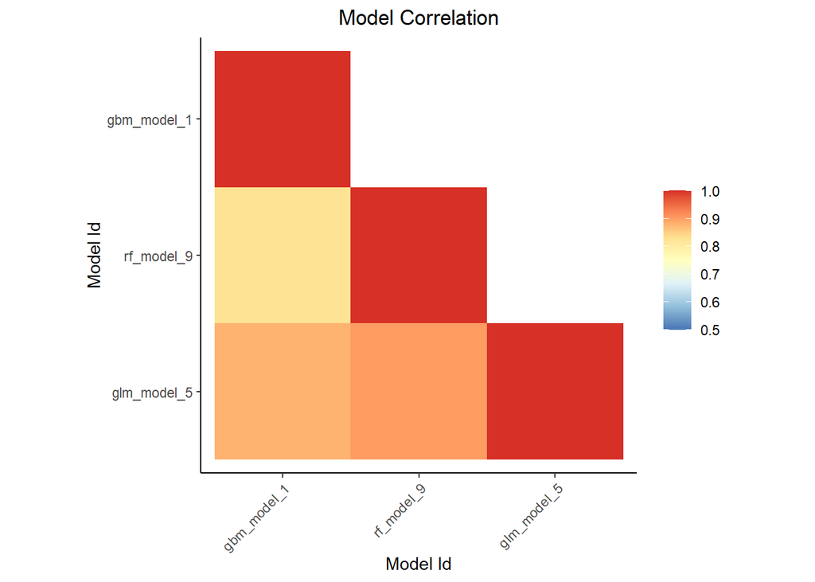

### f. Create a stacked ensemble model from the base learners.

Finally I create a stacked ensemble model from the GBM, GLM and RF models. The resulted AUC of the model was 0.6128 which outperformed the other models.

```
## Model Details:
## ==============
##
## H2OBinomialModel: stackedensemble
## Model ID:  StackedEnsemble_model_R_1616176533633_59931
## Number of Base Models: 3
##
## Base Models (count by algorithm type):
##
## drf gbm glm
##   1   1   1
##
## Metalearner:
##
## Metalearner algorithm: glm
## Metalearner hyperparameters:
##
##
## H2OBinomialMetrics: stackedensemble
## ** Reported on training data. **
##
## MSE:  0.2004
## RMSE:  0.4477
## LogLoss:  0.5885
## Mean Per-Class Error:  0.4382
## AUC:  0.6128
## AUCPR:  0.3815
## Gini:  0.2257
##
## Confusion Matrix (vertical: actual; across: predicted) for F1-optimal threshold:
##         No  Yes    Error        Rate
## No     630 1938 0.754673  =1938/2568
## Yes    129  930 0.121813   =129/1059
## Totals 759 2868 0.569892  =2067/3627
##
## Maximum Metrics: Maximum metrics at their respective thresholds
##                         metric threshold       value idx
## 1                       max f1  0.239284    0.473644 308
## 2                       max f2  0.195554    0.679236 377
## 3                 max f0point5  0.310930    0.399283 176
## 4                 max accuracy  0.430830    0.711607  14
## 5                max precision  0.547247    1.000000   0
## 6                   max recall  0.179420    1.000000 395
## 7              max specificity  0.547247    1.000000   0
## 8             max absolute_mcc  0.286366    0.158914 220
## 9   max min_per_class_accuracy  0.300235    0.578848 196
## 10 max mean_per_class_accuracy  0.286366    0.587179 220
## 11                     max tns  0.547247 2568.000000   0
## 12                     max fns  0.547247 1058.000000   0
## 13                     max fps  0.174251 2568.000000 399
## 14                     max tps  0.179420 1059.000000 395
## 15                     max tnr  0.547247    1.000000   0
## 16                     max fnr  0.547247    0.999056   0
## 17                     max fpr  0.174251    1.000000 399
## 18                     max tpr  0.179420    1.000000 395
##
## Gains/Lift Table: Extract with `h2o.gainsLift(<model>, <data>)` or `h2o.gainsLift(<model>, valid=<T/F>, xval=<T/F>)`
```

```
## [1] 0.6128
```

### g. Evaluate ensembles on validation set. Did it improve prediction?

So the best model became to be the stacked. On the validation it performed slightly worse, but not significantly compared to the others.

Models AUC on validation set

| model | auc |
| --- | --- |
| rf_model_9 | 0.5900 |
| glm_model_5 | 0.5707 |
| gbm_model_1 | 0.5897 |
| StackedEnsemble_model_R_1616176533633_59931 | 0.5851 |

### h. Evaluate the best performing model on the test set. How does performance compare to that of the validation set?

The AUC of the was 0.583 which is a slightly worse than the training data AUC.